# Precision for Medicine - Assessment

```r
install.packages('NanoStringNorm')
install.packages('NanoStringNorm')
install.packages('nlme')
```

```r
library(nlme)
library(NanoStringNorm)
library(ggplot2)
```

PREPORCESSING DATA

Annotation file is in the .CSV format. distinguish baseline and post-treatment created two separate directories. Read annotation file stored into “precision_for_medicine_annotation” data frame. Created two separate data framework for baseline and post-treatment.

Read baseline and post-treatment RCC files into two different baseline.mRNA and post_treatment.mRNA nanostring variable variable.

```r
precision_for_medicine_annotation <- read.csv2("case_study_datascientist_data/case_study_annotations.csv",header = TRUE,sep=",")
baseline <- subset(precision_for_medicine_annotation,visit == "Baseline")
post_treatment <- subset(precision_for_medicine_annotation, visit =="Post-Treatment")
baseline.mRNA <- read.markup.RCC(rcc.path = "case_study_datascientist_data/base_line",rcc.pattern = "*.RCC|*.rcc",exclude = NULL,include = NULL,nprobes = -1)
post_treatment.mRNA <- read.markup.RCC(rcc.path = "case_study_datascientist_data/post_treatment",rcc.pattern = "*.RCC|*.rcc",exclude = NULL,include = NULL,nprobes = -1)
```

Problem 3.1 (quality control)

Normalize mRNA expression data from the NanoString platform using NanoStringNorm Create separate NanoStringNorm object for baseline.mRNA and post_treatment.mRNA nanostring variable variable. Data is in the matrix format to generate heat maps.

```r
baseline.mRNA.norm <- NanoStringNorm(
  x = baseline.mRNA,
  anno = NA,
  CodeCount = 'geo.mean',
  Background = 'mean',
  SampleContent = 'housekeeping.geo.mean',
  round.values = TRUE,
  take.log = TRUE,
  return.matrix.of.endogenous.probes = TRUE
)
```

```
##############################
### NanoStringNorm v1.1.21 ###
##############################

There are 5 samples and 130 Endogenous genes

Background: After correction 5 samples and 127
    Endogenous genes have less than 90% missing.

log: Setting values less than 1 to 1 in order to calculate the log in positive space.
```

```r
post_treatment.mRNA.norm <- NanoStringNorm(
  x = post_treatment.mRNA,
  anno = NA,
  CodeCount = 'geo.mean',
  Background = 'mean',
  SampleContent = 'housekeeping.geo.mean',
  round.values = TRUE,
  take.log = TRUE,
  return.matrix.of.endogenous.probes = TRUE
)
```

```
##############################
### NanoStringNorm v1.1.21 ###
##############################

There are 5 samples and 130 Endogenous genes

Background: After correction 5 samples and 125
    Endogenous genes have less than 90% missing.

log: Setting values less than 1 to 1 in order to calculate the log in positive space.
```

By considering the data required as matrix format to display we have used ‘return.matrix.of.endogenous.probes’ while normalizing nanoString heat and use Transpose function to get appropriate format.

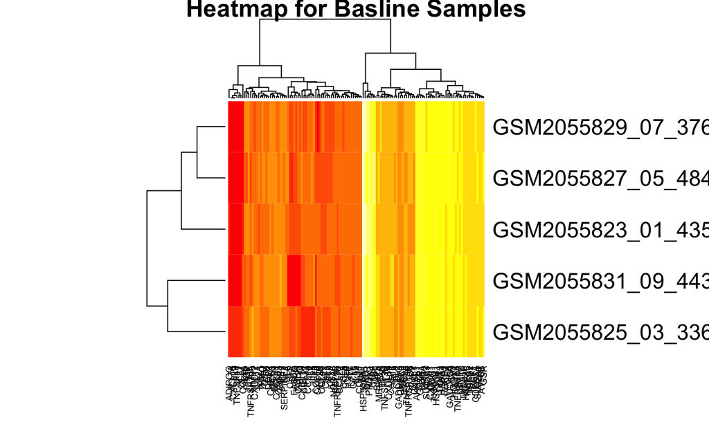

```r
heatmap(t(baseline.mRNA.norm),main = "Heatmap for Basline Samples")
```

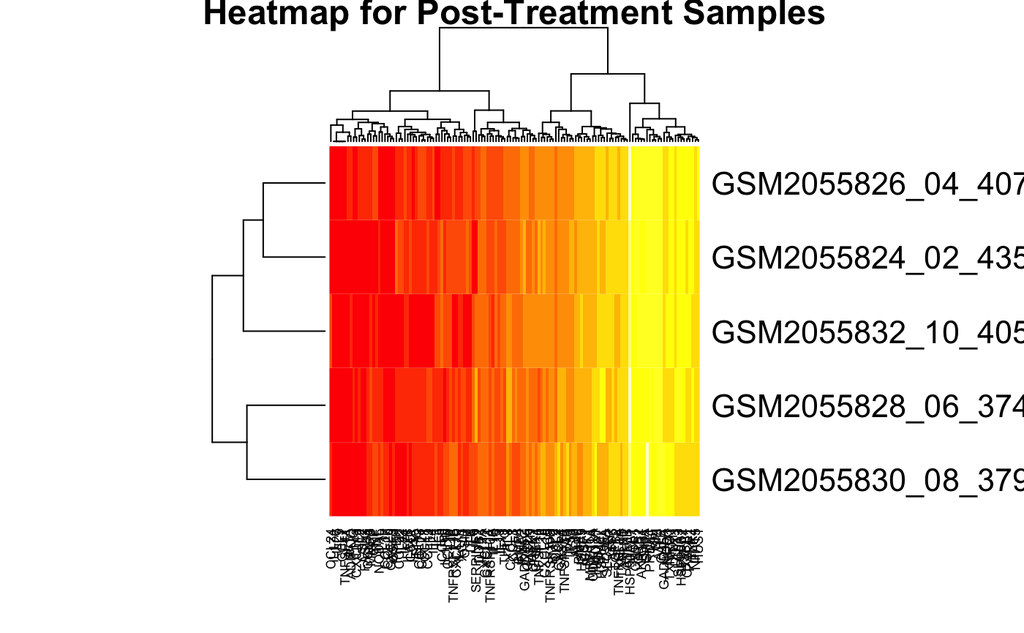

```r
heatmap(t(post_treatment.mRNA.norm), main = "Heatmap for Post-Treatment Samples")
```

Problem 3.2 (data analysis)

Subset CXCL1 and MCL1 values from Baseline/Post-Treatment sample and stored into the separate data frame.

```r
 data_CXCL1_MCL1 <- rbind(data.frame(sample = baseline$subjectid ,time_point = baseline$visit,CXCL1 = baseline.mRNA.norm["CXCL1",],MCL1 = baseline.mRNA.norm["MCL1",]),data.frame(sample= post_treatment$subjectid,time_point = post_treatment$visit,CXCL1 = post_treatment.mRNA.norm["CXCL1",],MCL1 = post_treatment.mRNA.norm["MCL1",]))
data_CXCL1_MCL1
```

|  | sample | time_point | CXCL1 | MCL1 |
| --- | --- | --- | --- | --- |
| GSM2055823_01_4353_PD_mRNA | 1 | Baseline | 7.524 | 11.90 |
| GSM2055825_03_3366_PD_mRNA | 2 | Baseline | 7.651 | 12.00 |
| GSM2055827_05_4846_PD_mRNA | 3 | Baseline | 6.943 | 11.63 |
| GSM2055829_07_3760_PD_mRNA | 4 | Baseline | 8.205 | 11.73 |
| GSM2055831_09_4436_PD_mRNA | 5 | Baseline | 7.248 | 11.91 |
| GSM2055824_02_4355_PD_mRNA | 1 | Post-Treatment | 6.209 | 11.46 |
| GSM2055826_04_4078_PD_mRNA | 2 | Post-Treatment | 5.728 | 11.49 |
| GSM2055828_06_3746_PD_mRNA | 3 | Post-Treatment | 9.433 | 12.92 |
| GSM2055830_08_3790_PD_mRNA | 4 | Post-Treatment | 5.858 | 12.29 |
| GSM2055832_10_4050_PD_mRNA | 5 | Post-Treatment | 6.190 | 11.14 |

Display difference from Baseline/Post-Treatment sample. (CXCL1 and MCL1 values from Baseline/Post-Treatment sample) using BOXPLOT

```
Ignoring unknown parameters: range
```

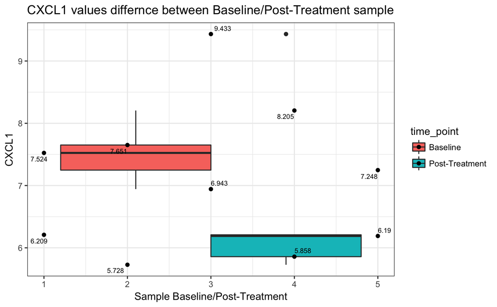

```r
ggplot(data = data_CXCL1_MCL1, aes(x=sample, y=CXCL1))  + geom_boxplot(aes(fill=time_point),stat = "boxplot",range=0.5) + geom_point(aes(fill=time_point),stat = "identity") + ggrepel::geom_text_repel(aes(label = CXCL1), color = "black", size = 2.5, segment.color = "grey") +  labs (x= "Sample Baseline/Post-Treatment", y = "CXCL1") + ggtitle("CXCL1 values differnce between Baseline/Post-Treatment sample") + theme_bw()
```

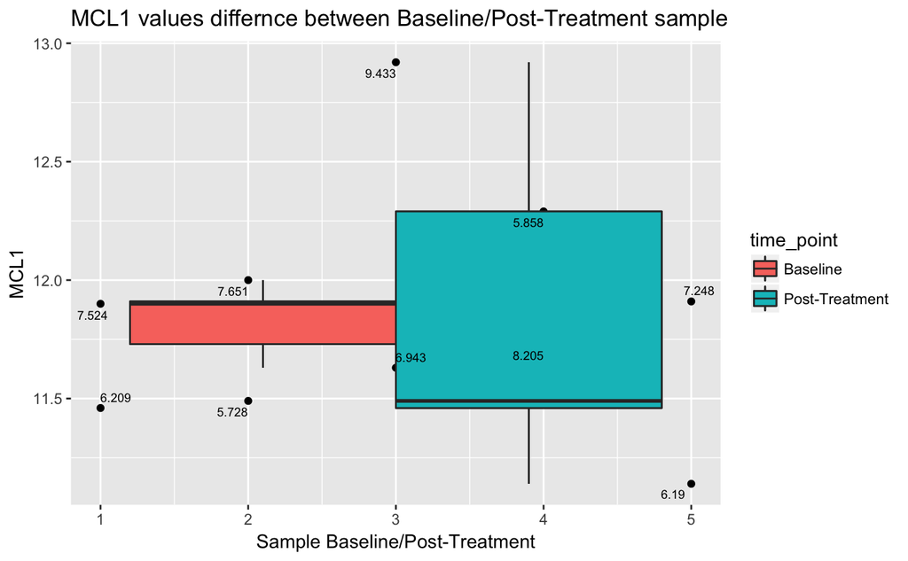

```r
ggplot(data = data_CXCL1_MCL1, aes(x=sample, y=MCL1))  + geom_boxplot(aes(fill=time_point),stat = "boxplot") + geom_point(aes(fill=time_point)) + geom_boxplot(aes(fill=time_point),stat = "boxplot") + ggrepel::geom_text_repel(aes(label = CXCL1), color = "black", size = 2.5, segment.color = "grey") + labs (x= "Sample Baseline/Post-Treatment", y = "MCL1") + ggtitle("MCL1 values differnce between Baseline/Post-Treatment sample")
```

```r
NA
```

```r
summary(data_CXCL1_MCL1)
```

```
     sample           time_point     CXCL1            MCL1
 Min.   :1   Baseline      :5    Min.   :5.728   Min.   :11.14
 1st Qu.:2   Post-Treatment:5    1st Qu.:6.195   1st Qu.:11.53
 Median :3                       Median :7.096   Median :11.81
 Mean   :3                       Mean   :7.099   Mean   :11.85
 3rd Qu.:4                       3rd Qu.:7.619   3rd Qu.:11.98
 Max.   :5                       Max.   :9.433   Max.   :12.92
```

EXTRA/OPTIONAL

Display difference from Baseline/Post-Treatment sample. (CXCL1 and MCL1 values from Baseline/Post-Treatment sample) using BAR CHART

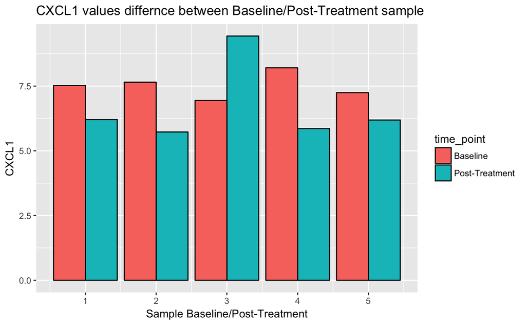

```r
 #CXCL1 values differnce between Baseline/Post-Treatment sample
 data_CXCL1 <- rbind(data.frame(sample = baseline$subjectid ,time_point = baseline$visit,CXCL1 = baseline.mRNA.norm["CXCL1",]),data.frame(sample= post_treatment$subjectid,time_point = post_treatment$visit,CXCL1 = post_treatment.mRNA.norm["CXCL1",]))

ggplot(data_CXCL1, aes(x=sample,y = CXCL1,fill = time_point)) + geom_bar(stat="identity",position=position_dodge(),colour="black") + labs (x= "Sample Baseline/Post-Treatment", y = "CXCL1") + ggtitle("CXCL1 values differnce between Baseline/Post-Treatment sample")
```

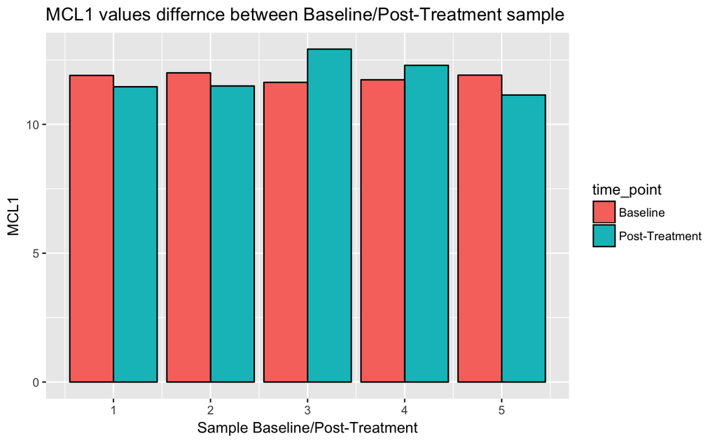

```r
 #MCL1 values differnce between Baseline/Post-Treatment sample
 data_MCL1 <- rbind(data.frame(sample = baseline$subjectid ,time_point = baseline$visit,MCL1 = baseline.mRNA.norm["MCL1",]),data.frame(sample= post_treatment$subjectid,time_point = post_treatment$visit,MCL1 = post_treatment.mRNA.norm["MCL1",]))

ggplot(data_MCL1, aes(x=sample,y = MCL1,fill = time_point)) + geom_bar(stat="identity",position=position_dodge(),colour="black") + labs (x= "Sample Baseline/Post-Treatment", y = "MCL1") + ggtitle("MCL1 values differnce between Baseline/Post-Treatment sample")
```

```r
NA
```

Problem 3.3 (reporting)

Normalize mRNA expression data from the NanoString platform using NanoStringNorm.

To get all reports using plot NanoStringNorm function, the data required as the NanoStringNorm format to get all reports. we have used ‘return.matrix.of.endogenous.probes’ as the FALSE parameter while normalizing nanoString.

```r
baseline.mRNA.normN <- NanoStringNorm(
  x = baseline.mRNA,
  anno = NA,
  CodeCount = 'geo.mean',
  Background = 'mean',
  SampleContent = 'housekeeping.geo.mean',
  round.values = TRUE,
  take.log = TRUE,
  return.matrix.of.endogenous.probes = FALSE
)
```

```
##############################
### NanoStringNorm v1.1.21 ###
##############################

There are 5 samples and 130 Endogenous genes

Background: After correction 5 samples and 127
    Endogenous genes have less than 90% missing.

log: Setting values less than 1 to 1 in order to calculate the log in positive space.
```

```r
post_treatment.mRNA.normN <- NanoStringNorm(
  x = post_treatment.mRNA,
  anno = NA,
  CodeCount = 'geo.mean',
  Background = 'mean',
  SampleContent = 'housekeeping.geo.mean',
  round.values = TRUE,
  take.log = TRUE,
  return.matrix.of.endogenous.probes = FALSE
)
```

```
##############################
### NanoStringNorm v1.1.21 ###
##############################

There are 5 samples and 130 Endogenous genes

Background: After correction 5 samples and 125
    Endogenous genes have less than 90% missing.

log: Setting values less than 1 to 1 in order to calculate the log in positive space.
```

A brief report with all types: Here, Used sperate reports for the Baseline Sample Report and Post Treatment Sample Report. We can use the single report as well. I considered the separate report to understand the report correctly.

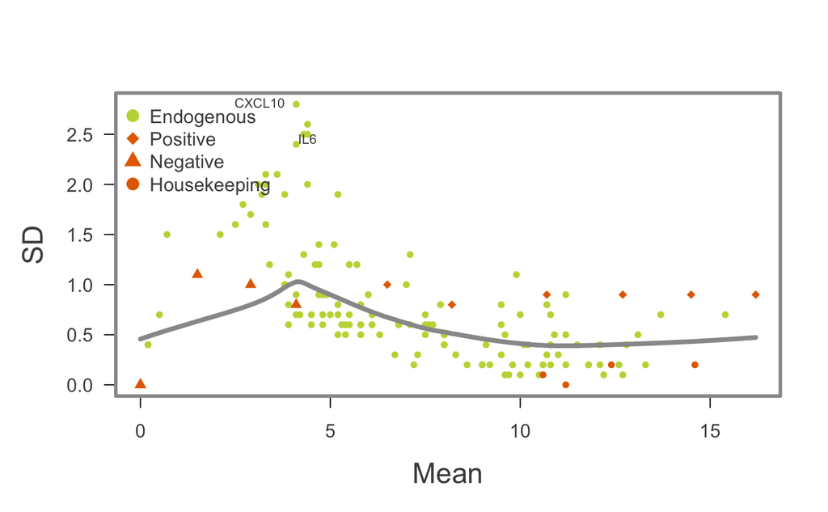

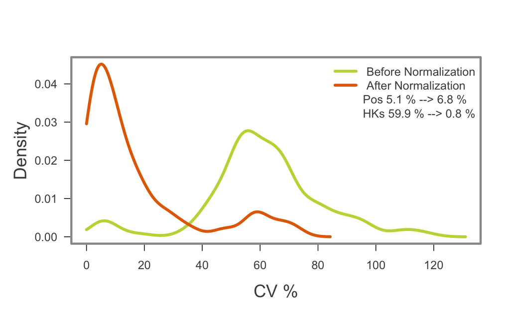

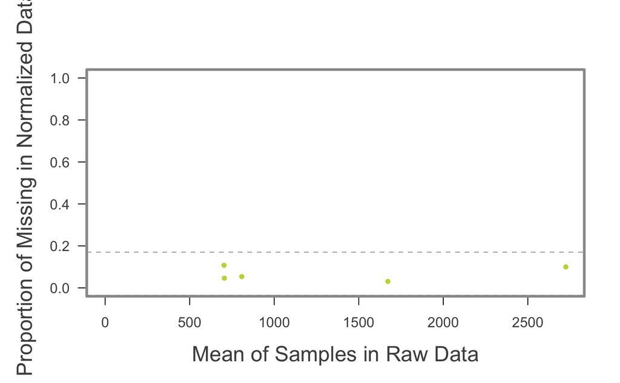

```
Plot.NanoStringNorm: no traits or plates for batch effects.  skipping plot.
```

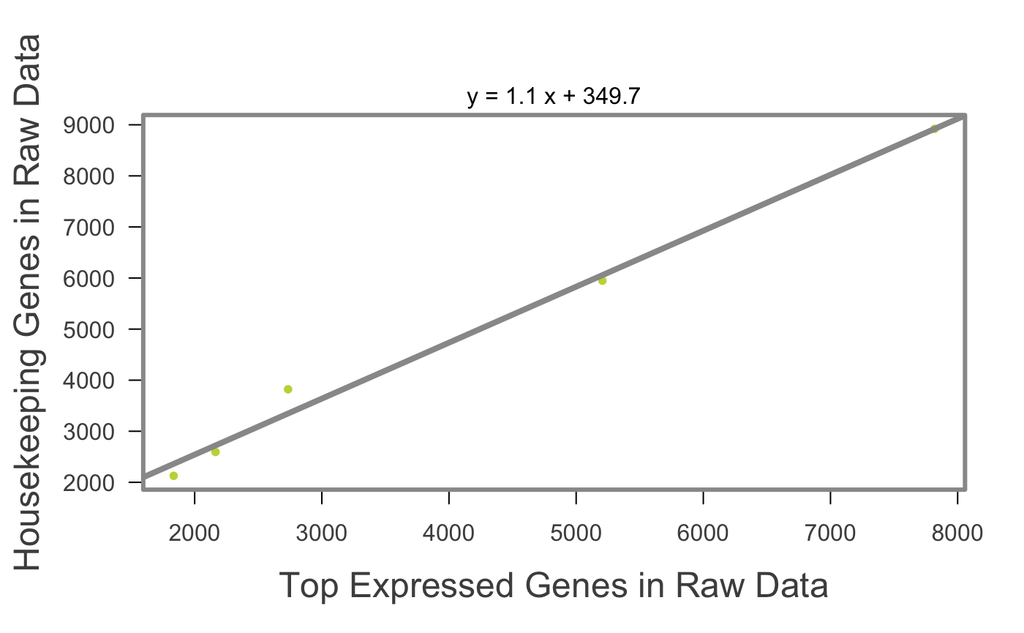

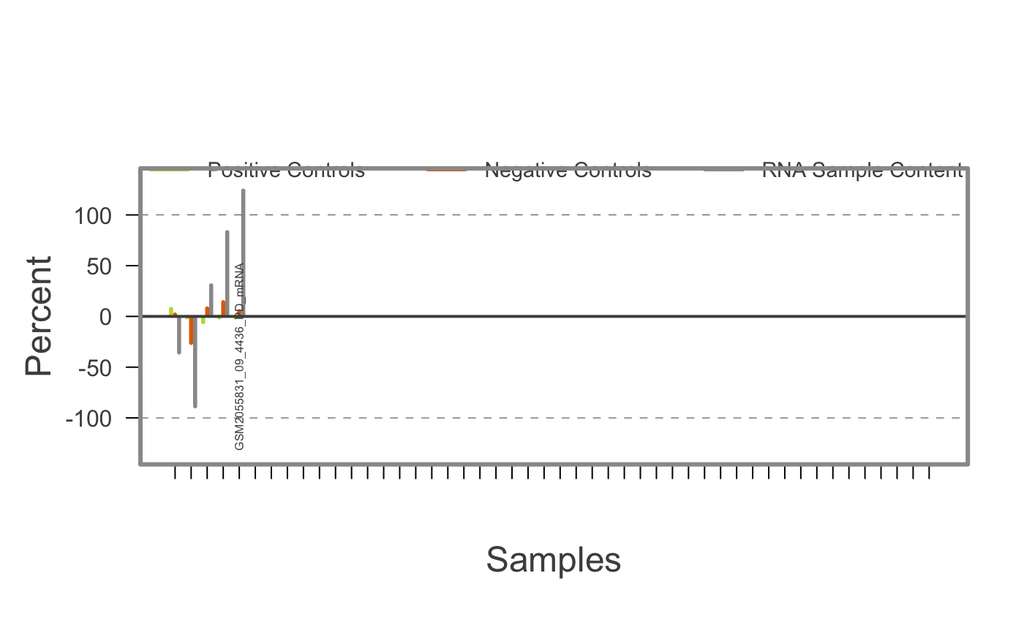

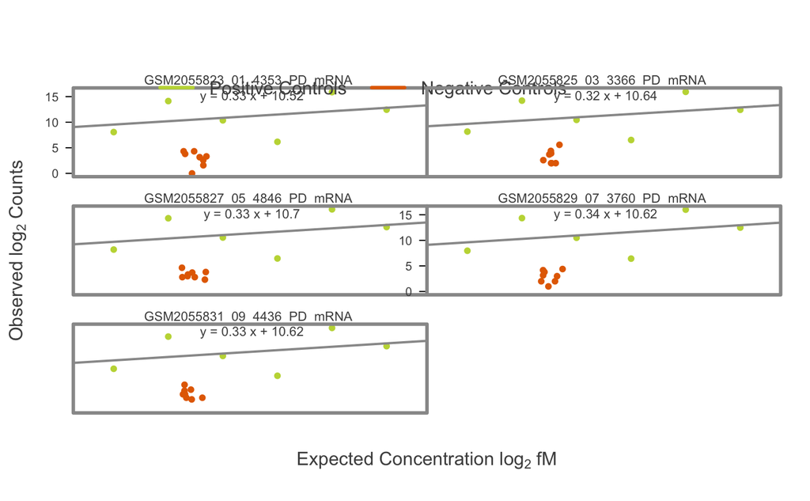

```r
 Plot.NanoStringNorm(x = baseline.mRNA.normN,label.best.guess = TRUE,plot.type = 'all', title = "Bseline Sample Report")
```

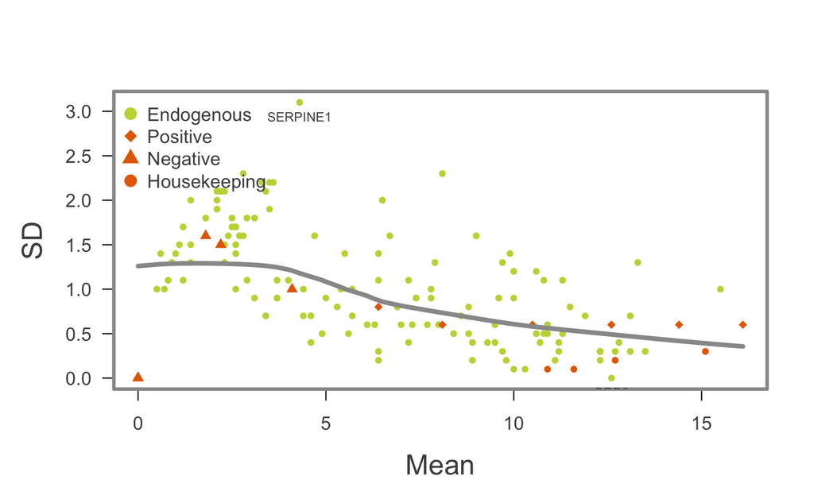

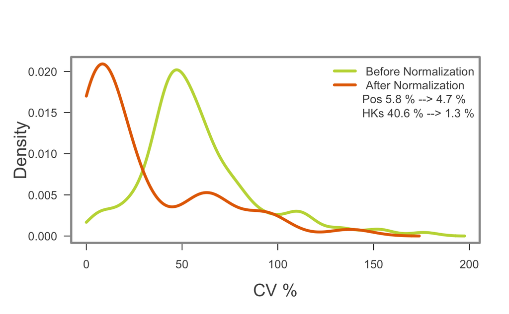

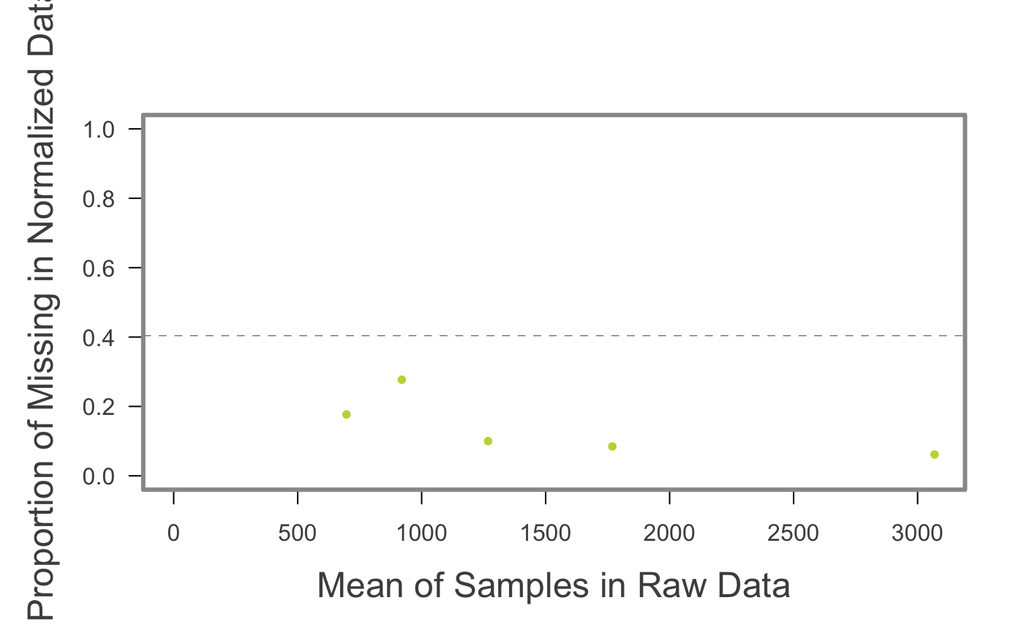

```
Plot.NanoStringNorm: no traits or plates for batch effects.  skipping plot.
```

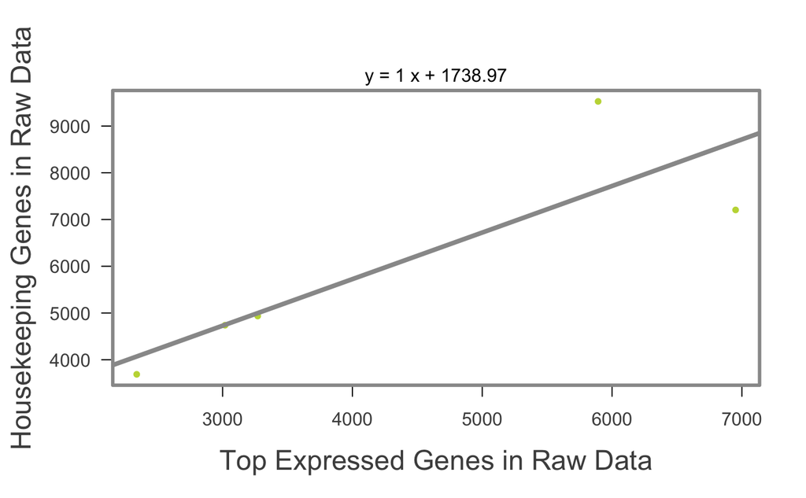

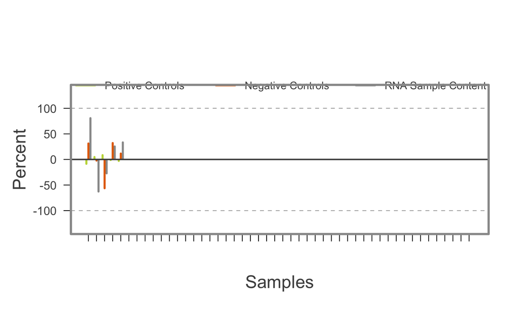

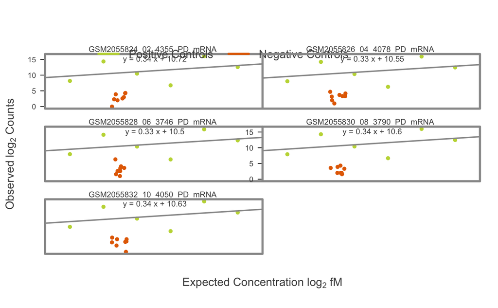

```r
 Plot.NanoStringNorm(x = post_treatment.mRNA.normN,label.best.guess = TRUE,plot.type = 'all', title = "Post Treatment Sample Report")
```

```r
NA
```

Thanks For consideration !!!